# Drumming regional variation: pdfas, repdfas, glmms statistics

Vesta Eleuteri

2025-04-04

# Introduction

This document accompanies the manuscript “Chimpanzee drumming shows rhythmicity and subspecies variation” Vesta Eleuteri et al. (2025).

Here we tested for regional variation in drumming by comparing drumming structure across communities, across populations, and between subspecies. We first used permuted discriminant function analyses (pDFA) to test for the group differences and then used repeated discriminant function analyses (repDFA) and generalized linear mixed models (glmms) to identify the key variables discriminating the groups in significant pDFAs.

Here we also tested for regional variation in drumming behaviour by comparing the timing of drumming onset during pant-hoot vocalizations across communities, across populations, and between subspecies. We used glmms to test for the group differences.

# Preliminaries

## Load packages, functions, data

```r
# for easy loading of packages
if (!require("pacman")) install.packages("pacman")
# load packages
#**to install cfp package run: "devtools::install_github("gobbios/cfp")"
p_load("here", "devtools", "gobbios/cfp", "MASS", "lmerTest", "lme4", "MuMIn", "dplyr", "knitr", "kableExtra", "rmdformats")
here <- here::here

# for relative file paths (e.g. here('Input', 'file.csv'))
here::i_am(file.path("reg_var_stats.Rmd"))
```

```
## here() starts at /Users/ve/Desktop/Drumming/Acoustic data analyses 2023/Analyses
```

```r
# get custom R functions
source(here("functions", "pdfa_functions.r"))
source(here("functions", "repDFA_nested.r"))
source(here("functions", "diagnostic_fcns.r"))
source(here("functions", "glmm_stability.r"))
source(here("functions", "boot_glmm.r"))

# load custom ggplot theme
source(here("theme_drumming.R"))

# set knitr options
knitr::opts_chunk$set(echo = TRUE, warning = FALSE, message = FALSE, out.width = "100%", fig.height = 10, fig.width = 10, comment = NA)

# load data
xdata <- read.csv(here("dataframes", "drumming_wide.csv"))
```

# Descriptives

## Descriptives drumming measures community

```r
descriptives_com <- xdata %>%
  group_by(Subspecies, Population, Community) %>%
  dplyr::summarise(
    Number_Drums = n(),
    Mean_N_hits = round(mean(N_hits, na.rm = TRUE), 3),
    SD_N_hits = round(sd(N_hits, na.rm = TRUE), 3),
    Mean_Bout_Duration = round(mean(Total_bout_duration, na.rm = TRUE), 3),
    SD_Bout_Duration = round(sd(Total_bout_duration, na.rm = TRUE), 3),
    Mean_Bout_cv = round(mean(Bout_cv, na.rm = TRUE), 3),
    SD_Bout_cv = round(sd(Bout_cv, na.rm = TRUE), 3),
    Mean_Bout_npvi = round(mean(Bout_npvi, na.rm = TRUE), 3),
    SD_Bout_npvi = round(sd(Bout_npvi, na.rm = TRUE), 3),
    Mean_Entropy = round(mean(Bout_entropy, na.rm = TRUE), 3),
    SD_Entropy = round(sd(Bout_entropy, na.rm = TRUE), 3),
    .groups = "drop"
  )
kable(descriptives_com, format = "html", caption = "Descriptives drumming measures community") %>%
  kable_styling("striped", full_width = FALSE)
```

Descriptives drumming measures community

| Subspecies | Population | Community | Number_Drums | Mean_N_hits | SD_N_hits | Mean_Bout_Duration | SD_Bout_Duration | Mean_Bout_cv | SD_Bout_cv | Mean_Bout_npvi | SD_Bout_npvi | Mean_Entropy | SD_Entropy |
| --- | --- | --- | --- | --- | --- | --- | --- | --- | --- | --- | --- | --- | --- |
| Eastern | Budongo | Sonso | 73 | 5.740 | 3.123 | 1.260 | 0.807 | 0.680 | 0.331 | 100.142 | 51.528 | 1.009 | 0.980 |
| Eastern | Budongo | Waibira | 64 | 4.688 | 2.376 | 0.914 | 0.674 | 0.593 | 0.311 | 91.206 | 48.638 | 0.853 | 0.769 |
| Eastern | Gombe | Kasekela | 8 | 7.125 | 2.850 | 1.631 | 0.714 | 0.811 | 0.266 | 87.107 | 34.292 | 1.215 | 1.101 |
| Eastern | Kibale | Kanyawara | 17 | 5.529 | 2.503 | 1.101 | 0.637 | 0.619 | 0.288 | 92.524 | 47.887 | 1.403 | 0.844 |
| Western | Fongoli | Fongoli | 12 | 8.083 | 4.231 | 1.878 | 1.594 | 0.569 | 0.391 | 42.842 | 19.235 | 1.189 | 1.119 |
| Western | Nimba | Gahtoy | 10 | 10.700 | 4.111 | 1.380 | 0.736 | 0.443 | 0.288 | 47.539 | 22.483 | 2.687 | 2.731 |
| Western | Nimba | Tongbongbon | 24 | 7.958 | 3.782 | 1.457 | 0.847 | 0.534 | 0.406 | 58.088 | 32.110 | 1.268 | 1.989 |
| Western | Taï | East | 65 | 8.477 | 4.210 | 1.473 | 0.992 | 0.490 | 0.276 | 56.517 | 25.038 | 0.627 | 0.906 |
| Western | Taï | Middle | 22 | 6.636 | 3.001 | 1.178 | 0.715 | 0.459 | 0.267 | 61.129 | 30.675 | 1.169 | 1.134 |
| Western | Taï | North | 54 | 7.130 | 4.107 | 1.746 | 1.245 | 0.415 | 0.278 | 50.372 | 31.832 | 0.648 | 0.883 |
| Western | Taï | South | 22 | 9.500 | 6.232 | 1.416 | 1.076 | 0.577 | 0.411 | 64.301 | 27.137 | 1.169 | 1.706 |

## Descriptives drumming measures population

```r
descriptives_pop <- xdata %>%
  group_by(Subspecies, Population) %>%
  dplyr::summarise(
    Number_Drums = n(),
    Mean_N_hits = round(mean(N_hits, na.rm = TRUE), 3),
    SD_N_hits = round(sd(N_hits, na.rm = TRUE), 3),
    Mean_Bout_Duration = round(mean(Total_bout_duration, na.rm = TRUE), 3),
    SD_Bout_Duration = round(sd(Total_bout_duration, na.rm = TRUE), 3),
    Mean_Bout_cv = round(mean(Bout_cv, na.rm = TRUE), 3),
    SD_Bout_cv = round(sd(Bout_cv, na.rm = TRUE), 3),
    Mean_Bout_npvi = round(mean(Bout_npvi, na.rm = TRUE), 3),
    SD_Bout_npvi = round(sd(Bout_npvi, na.rm = TRUE), 3),
    Mean_Entropy = round(mean(Bout_entropy, na.rm = TRUE), 3),
    SD_Entropy = round(sd(Bout_entropy, na.rm = TRUE), 3),
    .groups = "drop" # Drop the grouping after summarising
  )
kable(descriptives_pop, format = "html", caption = "Descriptives drumming measures population") %>%
  kable_styling("striped", full_width = FALSE)
```

Descriptives drumming measures population

| Subspecies | Population | Number_Drums | Mean_N_hits | SD_N_hits | Mean_Bout_Duration | SD_Bout_Duration | Mean_Bout_cv | SD_Bout_cv | Mean_Bout_npvi | SD_Bout_npvi | Mean_Entropy | SD_Entropy |
| --- | --- | --- | --- | --- | --- | --- | --- | --- | --- | --- | --- | --- |
| Eastern | Budongo | 137 | 5.248 | 2.838 | 1.098 | 0.765 | 0.639 | 0.323 | 95.968 | 50.215 | 0.936 | 0.888 |
| Eastern | Gombe | 8 | 7.125 | 2.850 | 1.631 | 0.714 | 0.811 | 0.266 | 87.107 | 34.292 | 1.215 | 1.101 |
| Eastern | Kibale | 17 | 5.529 | 2.503 | 1.101 | 0.637 | 0.619 | 0.288 | 92.524 | 47.887 | 1.403 | 0.844 |
| Western | Fongoli | 12 | 8.083 | 4.231 | 1.878 | 1.594 | 0.569 | 0.391 | 42.842 | 19.235 | 1.189 | 1.119 |
| Western | Nimba | 34 | 8.765 | 4.023 | 1.435 | 0.806 | 0.507 | 0.374 | 54.985 | 29.669 | 1.685 | 2.285 |
| Western | Taï | 163 | 7.920 | 4.429 | 1.516 | 1.071 | 0.473 | 0.299 | 56.154 | 28.639 | 0.780 | 1.086 |

## Descriptives drumming measures subspecies

```r
descriptives_sub <- xdata %>%
  group_by(Subspecies) %>%
  dplyr::summarise(
    Number_Drums = n(),
    Mean_N_hits = round(mean(N_hits, na.rm = TRUE), 3),
    SD_N_hits = round(sd(N_hits, na.rm = TRUE), 3),
    Mean_Bout_Duration = round(mean(Total_bout_duration, na.rm = TRUE), 3),
    SD_Bout_Duration = round(sd(Total_bout_duration, na.rm = TRUE), 3),
    Mean_Bout_cv = round(mean(Bout_cv, na.rm = TRUE), 3),
    SD_Bout_cv = round(sd(Bout_cv, na.rm = TRUE), 3),
    Mean_Bout_npvi = round(mean(Bout_npvi, na.rm = TRUE), 3),
    SD_Bout_npvi = round(sd(Bout_npvi, na.rm = TRUE), 3),
    Mean_Entropy = round(mean(Bout_entropy, na.rm = TRUE), 3),
    SD_Entropy = round(sd(Bout_entropy, na.rm = TRUE), 3),
    .groups = "drop" # Drop the grouping after summarising
  )
kable(descriptives_sub, format = "html", caption = "Descriptives drumming measures subspecies") %>%
  kable_styling("striped", full_width = FALSE)
```

Descriptives drumming measures subspecies

| Subspecies | Number_Drums | Mean_N_hits | SD_N_hits | Mean_Bout_Duration | SD_Bout_Duration | Mean_Bout_cv | SD_Bout_cv | Mean_Bout_npvi | SD_Bout_npvi | Mean_Entropy | SD_Entropy |
| --- | --- | --- | --- | --- | --- | --- | --- | --- | --- | --- | --- |
| Eastern | 162 | 5.370 | 2.819 | 1.125 | 0.755 | 0.646 | 0.318 | 95.169 | 49.128 | 0.999 | 0.901 |
| Western | 209 | 8.067 | 4.346 | 1.524 | 1.067 | 0.484 | 0.317 | 55.200 | 28.417 | 0.951 | 1.388 |

## Descriptives drumming measures all

```r
descriptives_all <- xdata %>%
  dplyr::summarise(
    Number_Drums = n(),
    Mean_N_hits = round(mean(N_hits, na.rm = TRUE), 3),
    SD_N_hits = round(sd(N_hits, na.rm = TRUE), 3),
    Mean_Bout_Duration = round(mean(Total_bout_duration, na.rm = TRUE), 3),
    SD_Bout_Duration = round(sd(Total_bout_duration, na.rm = TRUE), 3),
    Mean_Bout_cv = round(mean(Bout_cv, na.rm = TRUE), 3),
    SD_Bout_cv = round(sd(Bout_cv, na.rm = TRUE), 3),
    Mean_Bout_npvi = round(mean(Bout_npvi, na.rm = TRUE), 3),
    SD_Bout_npvi = round(sd(Bout_npvi, na.rm = TRUE), 3),
    Mean_Entropy = round(mean(Bout_entropy, na.rm = TRUE), 3),
    SD_Entropy = round(sd(Bout_entropy, na.rm = TRUE), 3),
    .groups = "drop" # Drop the grouping after summarising
  )
kable(descriptives_all, format = "html", caption = "Descriptives drumming measures all") %>%
  kable_styling("striped", full_width = FALSE)
```

Descriptives drumming measures all

| Number_Drums | Mean_N_hits | SD_N_hits | Mean_Bout_Duration | SD_Bout_Duration | Mean_Bout_cv | SD_Bout_cv | Mean_Bout_npvi | SD_Bout_npvi | Mean_Entropy | SD_Entropy |
| --- | --- | --- | --- | --- | --- | --- | --- | --- | --- | --- |
| 371 | 6.889 | 3.984 | 1.349 | 0.963 | 0.555 | 0.327 | 72.652 | 43.569 | 0.972 | 1.199 |

# Analyses for regional variation in drumming structure

## Community pDFA

We first tested for regional variation using a pDFA to compare drumming structure across communities.

```r
set.seed(131)
pdfa.res.communities <- pDFA.nested(
  test.fac = "Pop_com_code", contr.fac = "Com_indiv_code",
  variables = c(
    "log.Total_bout_duration_c", "log.N_hits_c",
    "Bout_cv_c", "Bout_npvi_c", "Bout_entropy_c"
  ),
  restrict.by = NULL,
  n.contr.fac.levels.to.sel = NULL,
  n.to.sel.per.contr.fac.level = NULL, n.sel = 100, n.perm = 1000,
  pdfa.data = xdata
)
pdfa.res.communities$result
```

```
                   no.corr.classified.selected
                                      25.86000
          expected.no.corr.classified.selected
                                      22.67486
         percent.correctly.classified.selected
                                      39.18182
expected.percent.correctly.classified.selected
                                      34.35585
                                P.for.selected
                                       0.21400
                      no.corr.cross.classified
                                      68.10000
             expected.no.corr.cross.classified
                                      39.56810
                 percent.corr.cross.classified
                                      22.32787
        expected.percent.corr.cross.classified
                                      12.97315
                        P.for.cross.classified
                                       0.01000
                        no.levels.contr.factor
                                      47.00000
               no.levels.contr.factor.selected
                                      22.00000
                         no.levels.test.factor
                                      11.00000
                                      no.cases
                                     371.00000
                             no.cases.selected
                                      66.00000
    no.cases.selected.per.level.of.control.fac
                                       3.00000
                               no.permutations
                                    1000.00000
                          no.random.selections
                                     100.00000
```

**The pDFA is significant showing that drumming structure varies across communities. We thus used a repDFA to identify the key variables discriminating the communities.**

### Communtiy repDFA

```r
set.seed(5)
ImpVars_all_comms_allvabs <- repDFA_nested(xdata,
  testfactor = "Pop_com_code",
  balancefactor = c("Pop_com_code", "Com_indiv_code"),
  varnames = c(
    "log.Total_bout_duration_c", "log.N_hits_c",
    "Bout_cv_c", "Bout_npvi_c", "Bout_entropy_c"
  ),
  npercomb = 3, nrand = 1000
)

All_comms_allvabs_repDFA_res_df1 <- table(ImpVars_all_comms_allvabs$df1_best)
All_comms_allvabs_repDFA_res_df1
```

```
 Bout_npvi_c log.N_hits_c
         798          202
```

```r
All_comms_allvabs_repDFA_res_df2 <- table(ImpVars_all_comms_allvabs$df2_best)
All_comms_allvabs_repDFA_res_df2
```

```
                Bout_cv_c            Bout_entropy_c               Bout_npvi_c
                       29                       345                        73
             log.N_hits_c log.Total_bout_duration_c
                       20                       533
```

**The repDFA identified as key variables on discriminant 1: nPVI and Number of hits, on discriminant 2: total bout duration and entropy. We thus used glmms to test if these variables significantly vary across the communities.**

### Community glmm nPVI

```r
## Run model
Model_npvi <- lmer(Bout_npvi_c ~ Community + (1 | Com_indiv_code), data = xdata, REML = F)

## Full-null model comparison
null_Model_npvi <- lmer(Bout_npvi_c ~ (1 | Com_indiv_code), data = xdata, REML = F)
Chisq_Model_npvi <- as.data.frame(anova(null_Model_npvi, Model_npvi, test = "Chisq"))
Chisq_Model_npvi <- round(Chisq_Model_npvi, 3)
Chisq_Model_npvi
```

```
                npar      AIC      BIC    logLik -2*log(L)  Chisq Df Pr(>Chisq)
null_Model_npvi    3 3741.514 3753.263 -1867.757  3735.514     NA NA         NA
Model_npvi        13 3732.256 3783.167 -1853.128  3706.256 29.258 10      0.001
```

**nPVI significantly varies across communities.**

### Community glmm number of hits

```r
## Run model
Model_numhits <- lmer(log.N_hits_c ~ Community + (1 | Com_indiv_code), data = xdata, REML = F)

## Full-null model comparison
null_Model_numhits <- lmer(log.N_hits_c ~ (1 | Com_indiv_code), data = xdata, REML = F)
Chisq_Model_numhits <- as.data.frame(anova(null_Model_numhits, Model_numhits, test = "Chisq"))
Chisq_Model_numhits <- round(Chisq_Model_numhits, 3)
Chisq_Model_numhits
```

```
                   npar     AIC     BIC   logLik -2*log(L)  Chisq Df Pr(>Chisq)
null_Model_numhits    3 511.915 523.664 -252.958   505.915     NA NA         NA
Model_numhits        13 501.004 551.914 -237.502   475.004 30.912 10      0.001
```

**Number of hits significantly varies across communities.**

### Community glmm bout duration

```r
## Run model
Model_drumduration <- lmer(log.Total_bout_duration_c ~ Community + (1 | Com_indiv_code), data = xdata, REML = F)

## Full-null model comparison
null_Model_drumduration <- lmer(log.Total_bout_duration_c ~ (1 | Com_indiv_code), data = xdata, REML = F)
Chisq_Model_drumduration <- as.data.frame(anova(null_Model_drumduration, Model_drumduration, test = "Chisq"))
Chisq_Model_drumduration
```

```
                        npar      AIC      BIC    logLik -2*log(L)    Chisq Df
null_Model_drumduration    3 787.5523 799.3009 -390.7762  781.5523       NA NA
Model_drumduration        13 789.8177 840.7284 -381.9089  763.8177 17.73457 10
                        Pr(>Chisq)
null_Model_drumduration         NA
Model_drumduration       0.0596095
```

**Bout duration does not significantly vary across communities.**

### Community glmm entropy

```r
## Run model
Model_entropy <- lmer(Bout_entropy_c ~ Community + (1 | Com_indiv_code), data = xdata, REML = F)

## Full-null model comparison
null_Model_entropy <- lmer(Bout_entropy_c ~ (1 | Com_indiv_code), data = xdata, REML = F)
Chisq_Model_entropy <- as.data.frame(anova(null_Model_entropy, Model_entropy, test = "Chisq"))
Chisq_Model_entropy <- round(Chisq_Model_entropy, 3)
Chisq_Model_entropy
```

```
                   npar      AIC      BIC   logLik -2*log(L)  Chisq Df
null_Model_entropy    3 1150.653 1162.401 -572.326  1144.653     NA NA
Model_entropy        13 1158.379 1209.289 -566.189  1132.379 12.274 10
                   Pr(>Chisq)
null_Model_entropy         NA
Model_entropy           0.267
```

**Entropy does not significantly vary across communities.**

## Confirmatory Subspecies pDFA

```r
set.seed(126)
pdfa.res.subspecies <- pDFA.nested(
  test.fac = "Subspecies", contr.fac = "Com_indiv_code",
  variables = c(
    "log.Total_bout_duration_c", "log.N_hits_c",
    "Bout_cv_c", "Bout_npvi_c", "Bout_entropy_c"
  ), restrict.by = NULL,
  n.contr.fac.levels.to.sel = NULL,
  n.to.sel.per.contr.fac.level = NULL, n.sel = 100, n.perm = 1000,
  pdfa.data = xdata
)


pdfa.res.subspecies$result
```

```
                   no.corr.classified.selected
                                      91.11000
          expected.no.corr.classified.selected
                                      74.85211
         percent.correctly.classified.selected
                                      72.30952
expected.percent.correctly.classified.selected
                                      59.40644
                                P.for.selected
                                       0.00300
                      no.corr.cross.classified
                                     177.21000
             expected.no.corr.cross.classified
                                     132.63421
                 percent.corr.cross.classified
                                      72.33061
        expected.percent.corr.cross.classified
                                      54.13641
                        P.for.cross.classified
                                       0.00300
                        no.levels.contr.factor
                                      47.00000
               no.levels.contr.factor.selected
                                      42.00000
                         no.levels.test.factor
                                       2.00000
                                      no.cases
                                     371.00000
                             no.cases.selected
                                     126.00000
    no.cases.selected.per.level.of.control.fac
                                       3.00000
                               no.permutations
                                    1000.00000
                          no.random.selections
                                     100.00000
```

**The pDFA is significant showing that drumming structure varies between subspecies. We thus used a repDFA to identify the key variables discriminating the subspecies.**

### Subspecies repDFA

```r
set.seed(5)
ImpVars_sub_allvabs <- repDFA_nested(xdata,
  testfactor = "Subspecies",
  balancefactor = c("Subspecies", "Com_indiv_code"),
  varnames = c(
    "log.Total_bout_duration_c", "log.N_hits_c",
    "Bout_cv_c", "Bout_npvi_c", "Bout_entropy_c"
  ),
  npercomb = 3, nrand = 1000
)

Sub_allvabs_repDFA_res_df1 <- table(ImpVars_sub_allvabs$df1_best)
Sub_allvabs_repDFA_res_df1
```

```
 Bout_npvi_c log.N_hits_c
         975           25
```

**The repDFA idenfitied as most contributing variables on discriminant 1: nPVI and number of hits. We thus used glmms to test if these variables significantly discriminate the subspecies.**

### Subspecies glmm nPVI

```r
## Run model
Model_npvi_sub <- lmer(Bout_npvi_c ~ Subspecies + (1 | Com_indiv_code), data = xdata, REML = F)

## Full-null model comparison
null_Model_npvi_sub <- lmer(Bout_npvi_c ~ (1 | Com_indiv_code), data = xdata, REML = F)
Chisq_Model_npvi_sub <- as.data.frame(anova(null_Model_npvi_sub, Model_npvi_sub, test = "Chisq")) # sig
Chisq_Model_npvi_sub <- round(Chisq_Model_npvi_sub, 3)
Chisq_Model_npvi_sub
```

```
                    npar      AIC      BIC    logLik -2*log(L)  Chisq Df
null_Model_npvi_sub    3 3741.514 3753.263 -1867.757  3735.514     NA NA
Model_npvi_sub         4 3717.897 3733.562 -1854.949  3709.897 25.617  1
                    Pr(>Chisq)
null_Model_npvi_sub         NA
Model_npvi_sub               0
```

**nPVI significantly varies between subspecies.**

### Subspecies glmm number of hits

```r
## Run model
Model_nhits_sub <- lmer(log.N_hits_c ~ Subspecies + (1 | Com_indiv_code), data = xdata, REML = F)


## Full-null model comparison
null_Model_nhits_sub <- lmer(log.N_hits_c ~ (1 | Com_indiv_code), data = xdata, REML = F)
Chisq_Model_nhits_sub <- as.data.frame(anova(null_Model_nhits_sub, Model_nhits_sub, test = "Chisq")) # sig
Chisq_Model_nhits_sub <- round(Chisq_Model_nhits_sub, 3)
Chisq_Model_nhits_sub
```

```
                     npar     AIC     BIC   logLik -2*log(L)  Chisq Df
null_Model_nhits_sub    3 511.915 523.664 -252.958   505.915     NA NA
Model_nhits_sub         4 494.718 510.382 -243.359   486.718 19.198  1
                     Pr(>Chisq)
null_Model_nhits_sub         NA
Model_nhits_sub               0
```

**Number of hits also significantly varies between subspecies.**

Taken together, our results above show that -across both communities and subspecies- western chimpanzees drum with lower nPVI (i.e., variability between adjacent pairs of inter-hit intervals) and more hits in drumming bouts that eastern chimpanzees.

## Across subspecies Populations pDFA

**Because the sampled populations live in different habitat types, we used another pDFA to test whether ecology might affect drumming by comparing drumming structure across populations.**

```r
set.seed(128)
pdfa.res.populations <- pDFA.nested(
  test.fac = "Population", contr.fac = "Com_indiv_code",
  variables = c(
    "log.Total_bout_duration_c", "log.N_hits_c",
    "Bout_cv_c", "Bout_npvi_c", "Bout_entropy_c"
  ), restrict.by = NULL,
  n.contr.fac.levels.to.sel = NULL,
  n.to.sel.per.contr.fac.level = NULL, n.sel = 100, n.perm = 1000,
  pdfa.data = xdata
)


pdfa.res.populations$result
```

```
                   no.corr.classified.selected
                                      18.94000
          expected.no.corr.classified.selected
                                      18.21494
         percent.correctly.classified.selected
                                      52.61111
expected.percent.correctly.classified.selected
                                      50.59706
                                P.for.selected
                                       0.46700
                      no.corr.cross.classified
                                      84.84000
             expected.no.corr.cross.classified
                                      64.74884
                 percent.corr.cross.classified
                                      25.32537
        expected.percent.corr.cross.classified
                                      19.32801
                        P.for.cross.classified
                                       0.10200
                        no.levels.contr.factor
                                      47.00000
               no.levels.contr.factor.selected
                                      12.00000
                         no.levels.test.factor
                                       6.00000
                                      no.cases
                                     371.00000
                             no.cases.selected
                                      36.00000
    no.cases.selected.per.level.of.control.fac
                                       3.00000
                               no.permutations
                                    1000.00000
                          no.random.selections
                                     100.00000
```

**The pDFA is non-significant showing that drumming structure does not vary across all populations and thus suggesting that ecology may not impact drumming structure.**

But because the populations belong to different subspecies, we further assessed whether ecology may affect drumming structure while controlling for subspecies variation. We used two additional pDFAs comparing populations within each subspecies.

## Western populations pDFA

```r
xdata_TNF <- subset(xdata, Population %in% c("Tai", "Nimba", "Fongoli"))
xdata_TNF <- droplevels(xdata_TNF)

set.seed(136)
pdfa.res.TNFpopulations <- pDFA.nested(
  test.fac = "Population", contr.fac = "Com_indiv_code",
  variables = c(
    "log.Total_bout_duration_c", "log.N_hits_c",
    "Bout_cv_c", "Bout_npvi_c", "Bout_entropy_c"
  ), restrict.by = NULL,
  n.contr.fac.levels.to.sel = NULL,
  n.to.sel.per.contr.fac.level = NULL, n.sel = 100, n.perm = 1000,
  pdfa.data = xdata_TNF
)


pdfa.res.TNFpopulations$result
```

```
                   no.corr.classified.selected
                                      19.55000
          expected.no.corr.classified.selected
                                      17.72655
         percent.correctly.classified.selected
                                      81.45833
expected.percent.correctly.classified.selected
                                      73.86062
                                P.for.selected
                                       0.22800
                      no.corr.cross.classified
                                      13.05000
             expected.no.corr.cross.classified
                                      12.71705
                 percent.corr.cross.classified
                                      59.31818
        expected.percent.corr.cross.classified
                                      57.80477
                        P.for.cross.classified
                                       0.40100
                        no.levels.contr.factor
                                      10.00000
               no.levels.contr.factor.selected
                                       8.00000
                         no.levels.test.factor
                                       2.00000
                                      no.cases
                                      46.00000
                             no.cases.selected
                                      24.00000
    no.cases.selected.per.level.of.control.fac
                                       3.00000
                               no.permutations
                                    1000.00000
                          no.random.selections
                                     100.00000
```

### Eastern populations pDFA

```r
xdata_BKG <- subset(xdata, Population %in% c("Budongo", "Kibale", "Gombe"))
xdata_BKG <- droplevels(xdata_BKG)

set.seed(137)
pdfa.res.BKGpopulations <- pDFA.nested(
  test.fac = "Population", contr.fac = "Com_indiv_code",
  variables = c(
    "log.Total_bout_duration_c", "log.N_hits_c",
    "Bout_cv_c", "Bout_npvi_c", "Bout_entropy_c"
  ), restrict.by = NULL,
  n.contr.fac.levels.to.sel = NULL,
  n.to.sel.per.contr.fac.level = NULL, n.sel = 100, n.perm = 1000,
  pdfa.data = xdata_BKG
)


pdfa.res.BKGpopulations$result
```

```
                   no.corr.classified.selected
                                      13.33000
          expected.no.corr.classified.selected
                                      13.13833
         percent.correctly.classified.selected
                                      74.05556
expected.percent.correctly.classified.selected
                                      72.99072
                                P.for.selected
                                       0.43500
                      no.corr.cross.classified
                                      50.40000
             expected.no.corr.cross.classified
                                      52.76440
                 percent.corr.cross.classified
                                      35.00000
        expected.percent.corr.cross.classified
                                      36.64194
                        P.for.cross.classified
                                       0.54200
                        no.levels.contr.factor
                                      21.00000
               no.levels.contr.factor.selected
                                       6.00000
                         no.levels.test.factor
                                       3.00000
                                      no.cases
                                     162.00000
                             no.cases.selected
                                      18.00000
    no.cases.selected.per.level.of.control.fac
                                       3.00000
                               no.permutations
                                    1000.00000
                          no.random.selections
                                     100.00000
```

**The pDFA is non-significant showing that drumming structure does not vary across eastern populations.**

# Subspecies drumming measures stability over time

Here we test whether the drumming measures remain stable over time within the subspecies

```r
# convert recording date to datetime object
xdata$Recording_date <- as.Date(xdata$Date, format = "%d.%m.%y")
```

## Distribution of recording dates

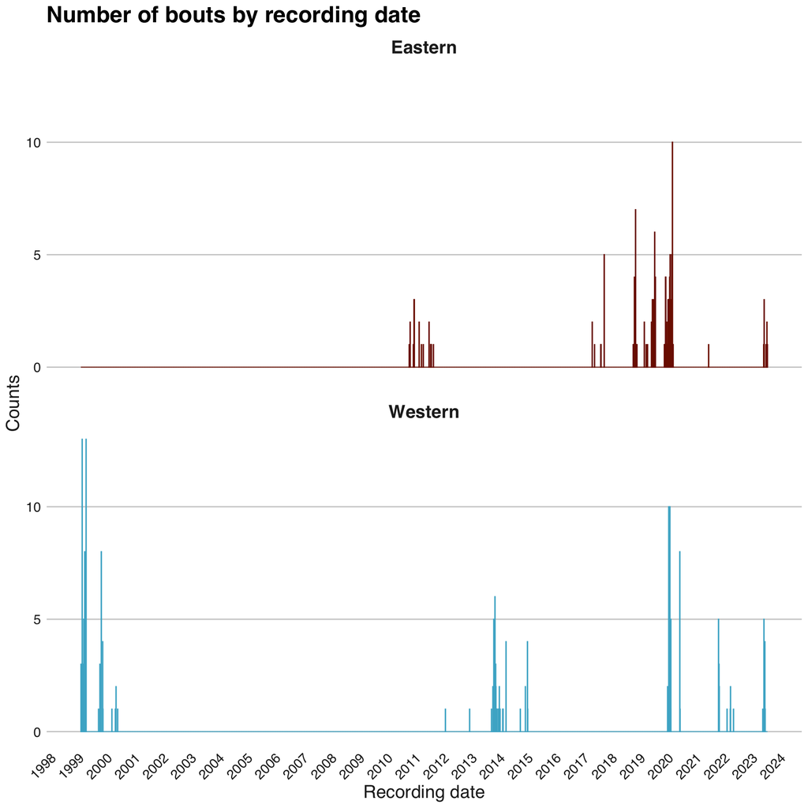

```r
ggplot(xdata, aes(x = Recording_date, fill = Subspecies, colour = Subspecies)) +
    geom_histogram(alpha = 0.6, binwidth = 3, show.legend = FALSE) +
    theme_drumming() +
    labs(x = "Recording date", y = "Counts", title = "Number of bouts by recording date") +
    facet_wrap(~Subspecies, ncol = 1) +
    scale_x_date(date_breaks = "1 year", date_labels = "%Y") +
    theme(axis.text.x = element_text(angle = 45, hjust = 1))
```

## Statistics

### Does nPVI remain stable across time?

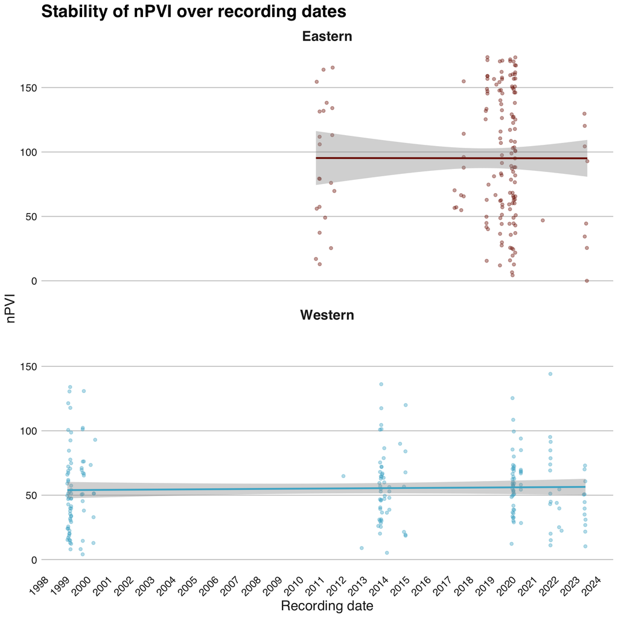

```r
# nPVI
ggplot(xdata, aes(x = Recording_date, y = Bout_npvi, color = Subspecies)) +
    geom_point(alpha = 0.4, show.legend = FALSE) +
    geom_smooth(method = "lm", show.legend = FALSE) +
    theme_drumming() +
    labs(x = "Recording date", y = "nPVI", title = "Stability of nPVI over recording dates") +
    facet_wrap(~Subspecies, ncol = 1) +
    scale_x_date(date_breaks = "1 year", date_labels = "%Y") +
    theme(axis.text.x = element_text(angle = 45, hjust = 1))
```

```r
ggsave(here("plots", "stability_npvi.svg"), width = 10, height = 10)
ggsave(here("plots", "stability_npvi.png"), width = 10, height = 10)
```

```r
mod <- lmer(Bout_npvi ~ Days_before_2024 * Subspecies + (1 | Com_indiv_code), data = xdata, REML = FALSE)
red <- lmer(Bout_npvi ~ Days_before_2024 + Subspecies + (1 | Com_indiv_code), data = xdata, REML = FALSE)
chisq.npvi <- as.data.frame(anova(red, mod, test = "chisq"))
chisq.npvi
```

```
    npar      AIC      BIC    logLik -2*log(L)     Chisq Df Pr(>Chisq)
red    5 3719.605 3739.186 -1854.803  3709.605        NA NA         NA
mod    6 3721.025 3744.522 -1854.512  3709.025 0.5804957  1  0.4461181
```

**nPVI remains stable across time within subspecies.**

## Does coefficient of variation remain stable across time?

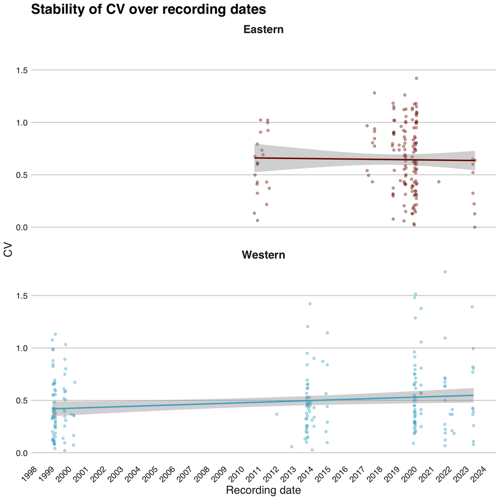

```r
ggplot(xdata, aes(x = Recording_date, y = Bout_cv, color = Subspecies)) +
    geom_point(alpha = 0.4, show.legend = FALSE) +
    geom_smooth(method = "lm", show.legend = FALSE) +
    theme_drumming() +
    labs(x = "Recording date", y = "CV", title = "Stability of CV over recording dates") +
    facet_wrap(~Subspecies, ncol = 1) +
    scale_x_date(date_breaks = "1 year", date_labels = "%Y") +
    theme(axis.text.x = element_text(angle = 45, hjust = 1))
```

```r
ggsave(here("plots", "stability_cv.svg"), width = 10, height = 10)
ggsave(here("plots", "stability_cv.png"), width = 10, height = 10)
```

```r
mod <- lmer(Bout_cv ~ Days_before_2024 * Subspecies + (1 | Com_indiv_code), data = xdata, REML = FALSE)
red <- lmer(Bout_cv ~ Days_before_2024 + Subspecies + (1 | Com_indiv_code), data = xdata, REML = FALSE)
chisq.cv <- as.data.frame(anova(red, mod, test = "chisq"))
chisq.cv
```

```
    npar      AIC      BIC    logLik -2*log(L)    Chisq Df Pr(>Chisq)
red    5 193.7486 213.3296 -91.87431  183.7486       NA NA         NA
mod    6 194.6981 218.1953 -91.34905  182.6981 1.050519  1  0.3053875
```

**Coefficient of variation remains stable across time within subspecies.**

## Does entropy remain stable across time?

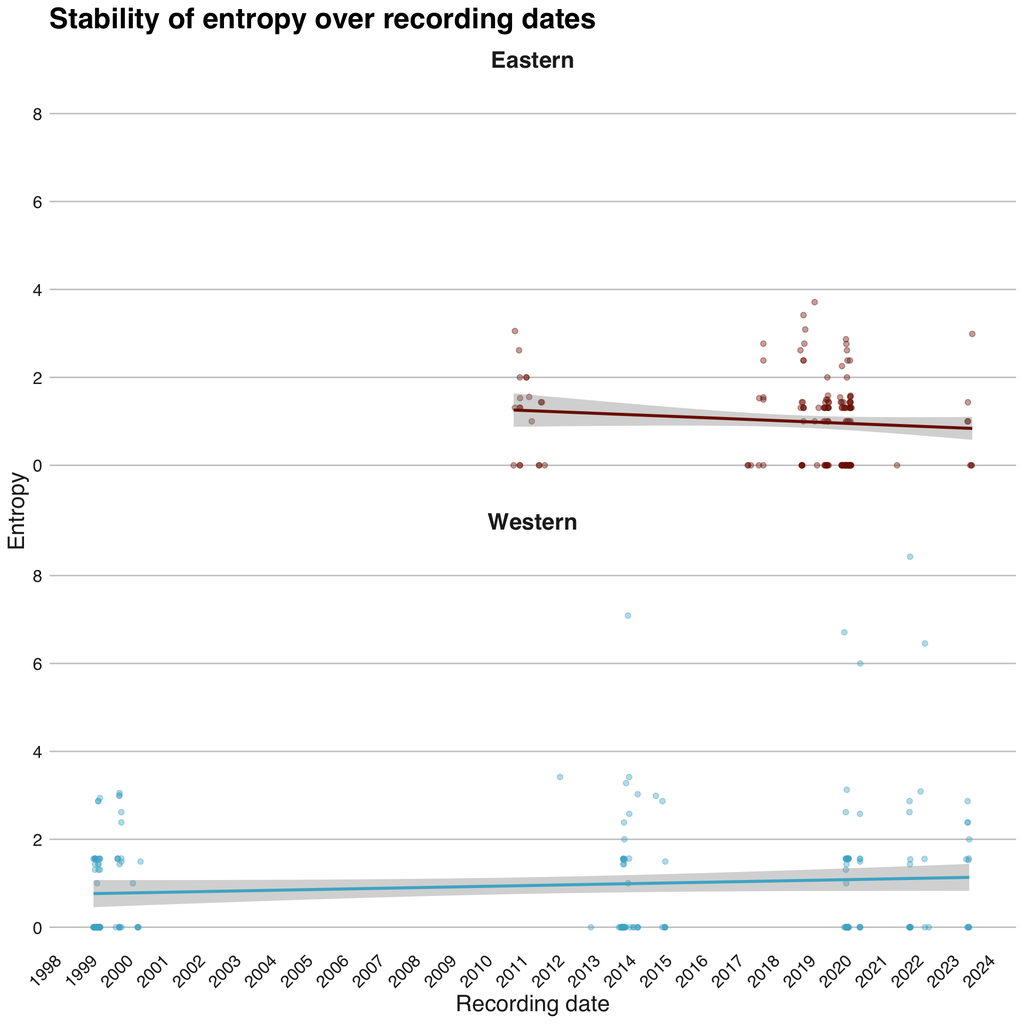

```r
ggplot(xdata, aes(x = Recording_date, y = Bout_entropy, color = Subspecies)) +
    geom_point(alpha = 0.4, show.legend = FALSE) +
    geom_smooth(method = "lm", show.legend = FALSE) +
    theme_drumming() +
    labs(x = "Recording date", y = "Entropy", title = "Stability of entropy over recording dates") +
    facet_wrap(~Subspecies, ncol = 1) +
    scale_x_date(date_breaks = "1 year", date_labels = "%Y") +
    theme(axis.text.x = element_text(angle = 45, hjust = 1))
```

```r
ggsave(here("plots", "stability_entropy.svg"), width = 10, height = 10)
ggsave(here("plots", "stability_entropy.png"), width = 10, height = 10)
```

```r
mod <- lmer(Bout_entropy ~ Days_before_2024 * Subspecies + (1 | Com_indiv_code), data = xdata, REML = FALSE)
red <- lmer(Bout_entropy ~ Days_before_2024 + Subspecies + (1 | Com_indiv_code), data = xdata, REML = FALSE)
chisq.entropy <- as.data.frame(anova(red, mod, test = "chisq"))
chisq.entropy
```

```
    npar      AIC      BIC    logLik -2*log(L)     Chisq Df Pr(>Chisq)
red    5 1154.618 1174.199 -572.3089  1144.618        NA NA         NA
mod    6 1156.171 1179.669 -572.0856  1144.171 0.4464226  1  0.5040387
```

**Entropy remains stable across time within subspecies.**

## Does number of hits remain stable across time?

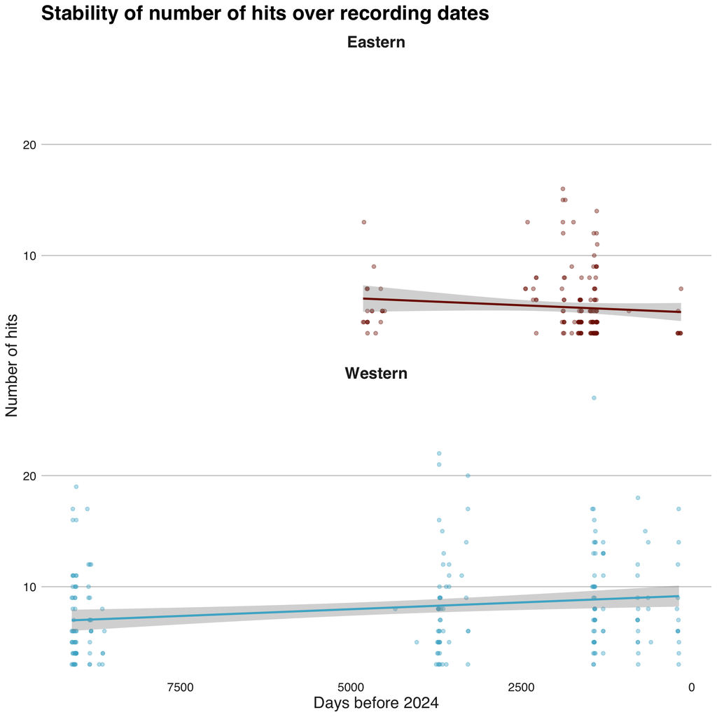

```r
ggplot(xdata, aes(x = Days_before_2024, y = N_hits, color = Subspecies)) +
    geom_point(alpha = 0.4, show.legend = FALSE) +
    geom_smooth(method = "lm", show.legend = FALSE) +
    theme_drumming() +
    labs(x = "Days before 2024", y = "Number of hits", title = "Stability of number of hits over recording dates") +
    facet_wrap(~Subspecies, ncol = 1) +
    scale_x_reverse()
```

```r
ggsave(here("plots", "stability_n_hits.svg"), width = 10, height = 10)
ggsave(here("plots", "stability_n_hits.png"), width = 10, height = 10)
```

```r
mod <- lmer(N_hits ~ Days_before_2024 * Subspecies + (1 | Com_indiv_code), data = xdata, REML = FALSE)
red <- lmer(N_hits ~ Days_before_2024 + Subspecies + (1 | Com_indiv_code), data = xdata, REML = FALSE)
chisq.N_hits <- as.data.frame(anova(red, mod, test = "chisq"))
chisq.N_hits
```

```
    npar      AIC      BIC    logLik -2*log(L)    Chisq Df Pr(>Chisq)
red    5 2018.802 2038.383 -1004.401  2008.802       NA NA         NA
mod    6 2019.313 2042.810 -1003.656  2007.313 1.489504  1  0.2222935
```

**Number of hits remains stable across time within subspecies.**

# Analyses for regional variation in drumming onset during pant-hoot

We last tested for regional variation in drumming behaviour using 3 glmms to compare the timing of drumming onset during pant-hoot vocalizations across communities, across populations, and between subspecies.

## Sort data

```r
levels(xdata$With_Ph)[levels(xdata$With_Ph) %in% c("with")] <- "With"
xdata_ph <- subset(xdata, Start_Ph %in% c("Build-Up", "Climax", "Let-Down", "roar", "Roar")) # keeping only drums starting in clear pant-hoot phases
xdata_ph <- droplevels(xdata_ph)
xdata_ph$Start_Ph <- factor(xdata_ph$Start_Ph) # conver to factor
levels(xdata_ph$Start_Ph)[levels(xdata_ph$Start_Ph) %in% c("Build-Up", "roar", "Roar")] <- "Before Climax Start" # rename level
levels(xdata_ph$Start_Ph)[levels(xdata_ph$Start_Ph) %in% c("Climax", "Let-Down")] <- "After Climax Start" # rename level

## Check frequencies of response variable
table(xdata_ph$Start_Ph, xdata_ph$Community) # South has 0 drums After Climax Start so remove level
xdata_ph <- subset(xdata_ph, Community != c("South")) # removed, n=302
xdata_ph <- droplevels(xdata_ph) # drop levels no observations
table(xdata_ph$Start_Ph, xdata_ph$Community)

## Dummy code response variable
xdata_ph$Start_Ph <- as.numeric(xdata_ph$Start_Ph == "Before Climax Start") # Dummy coded Before Climax Start as 1
```

## Community glmm

```r
## Run model
Model_start_ph_com <- glmer(Start_Ph ~ Community + (1 | Com_indiv_code), data = xdata_ph, family = binomial)

## Full-null model comparison
null_Model_start_ph_com <- glmer(Start_Ph ~ (1 | Com_indiv_code), data = xdata_ph, family = binomial)
Chisq_Model_start_ph_com <- as.data.frame(anova(null_Model_start_ph_com, Model_start_ph_com, test = "Chisq")) # sig
Chisq_Model_start_ph_com <- round(Chisq_Model_start_ph_com, 3)
Chisq_Model_start_ph_com
```

```
                        npar     AIC     BIC   logLik -2*log(L)  Chisq Df
null_Model_start_ph_com    2 306.177 313.598 -151.088   302.177     NA NA
Model_start_ph_com        11 305.514 346.329 -141.757   283.514 18.663  9
                        Pr(>Chisq)
null_Model_start_ph_com         NA
Model_start_ph_com           0.028
```

**The timing of drumming onset significantly varies across communities.**

## Population glmm

```r
## Run model
Model_start_ph_pop <- glmer(Start_Ph ~ Population + (1 | Com_indiv_code), data = xdata_ph, family = binomial)

## Full-null model comparison
null_Model_start_ph_pop <- glmer(Start_Ph ~ (1 | Com_indiv_code), data = xdata_ph, family = binomial)
Chisq_Model_start_ph_pop <- as.data.frame(anova(null_Model_start_ph_pop, Model_start_ph_pop, test = "Chisq"))
Chisq_Model_start_ph_pop <- round(Chisq_Model_start_ph_pop, 3)
Chisq_Model_start_ph_pop
```

```
                        npar     AIC     BIC   logLik -2*log(L) Chisq Df
null_Model_start_ph_pop    2 306.177 313.598 -151.088   302.177    NA NA
Model_start_ph_pop         7 301.537 327.510 -143.768   287.537 14.64  5
                        Pr(>Chisq)
null_Model_start_ph_pop         NA
Model_start_ph_pop           0.012
```

**The timing of drumming onset significantly varies across all populations.**

## Confirmatory subspecies glmm

```r
## Run model
Model_start_ph_sub <- glmer(Start_Ph ~ Subspecies + (1 | Com_indiv_code), data = xdata_ph, family = binomial)

## Full-null model comparison
null_Model_start_ph_sub <- glmer(Start_Ph ~ (1 | Com_indiv_code), data = xdata_ph, family = binomial)
Chisq_Model_start_ph_sub <- as.data.frame(anova(null_Model_start_ph_sub, Model_start_ph_sub, test = "Chisq"))
Chisq_Model_start_ph_sub <- round(Chisq_Model_start_ph_sub, 3)
Chisq_Model_start_ph_sub
```

```
                        npar     AIC     BIC   logLik -2*log(L) Chisq Df
null_Model_start_ph_sub    2 306.177 313.598 -151.088   302.177    NA NA
Model_start_ph_sub         3 293.797 304.928 -143.898   287.797 14.38  1
                        Pr(>Chisq)
null_Model_start_ph_sub         NA
Model_start_ph_sub               0
```

**The timing of drumming onset significantly varies between subspecies.**

Taken together, we find that western chimpanzees start to drum earlier in the pant-hoot than eastern chimpanzees typically during the build-up phase.

# References

Vesta Eleuteri, Jelle van der Werff, Wytse Wilhelm, Adrian Soldati, Catherine Crockford, Nisarg Desai, Pawel Fedurek, Maegan Fitzgerald, Kirsty E. Graham, Kathelijne Koops, Jill Pruetz, Liran Samuni, Katie Slocombe, Angela Stoeger, Michael L. Wilson, Roman Wittig, Klaus Zuberbühler, Henry D. Camara, Gnan Mamy, … Catherine Hobaiter. (2025). Chimpanzee drumming shows rhythmicity and subspecies variation. *Current Biology*.